# Final Project

Keith Williams (800690755)

11/23/2016

```r
data_file <- '../data/data_6115.txt'
dat <- read_delim(data_file, delim = "\t")
glimpse(dat)
```

```
## Observations: 200
## Variables: 6
## $ V1 <dbl> -0.50298395, 2.19135919, 2.74297817, 1.30028745, 2.66703447...
## $ V2 <dbl> 0.09791495, 0.99563352, 0.32055252, 0.39772641, 0.55322525,...
## $ V3 <dbl> -0.13871249, -1.51139625, -1.26006355, -0.51996537, 0.86923...
## $ V4 <dbl> -0.01358203, -1.50479678, -0.40391654, -0.20680396, 0.48088...
## $ V5 <dbl> 0.0018839968, 2.2743442171, 0.5089605137, 0.1075308978, 0.4...
## $ V6 <dbl> 0.009587338, 0.991286114, 0.102753916, 0.158186294, 0.30605...
```

# 1.

**Write the dataset to a file in excel format**

```r
# note: dir.exists() requires R > 3.2.0
data_path <- '../data'
out_filename <- 'out_data.csv'
if (!dir.exists(data_path)) {
    dir.create(data_path)
}
write.csv(dat, file.path(data_path, out_filename))
```

# 2.

**Find the sample correlation between the response and each of the covariates**

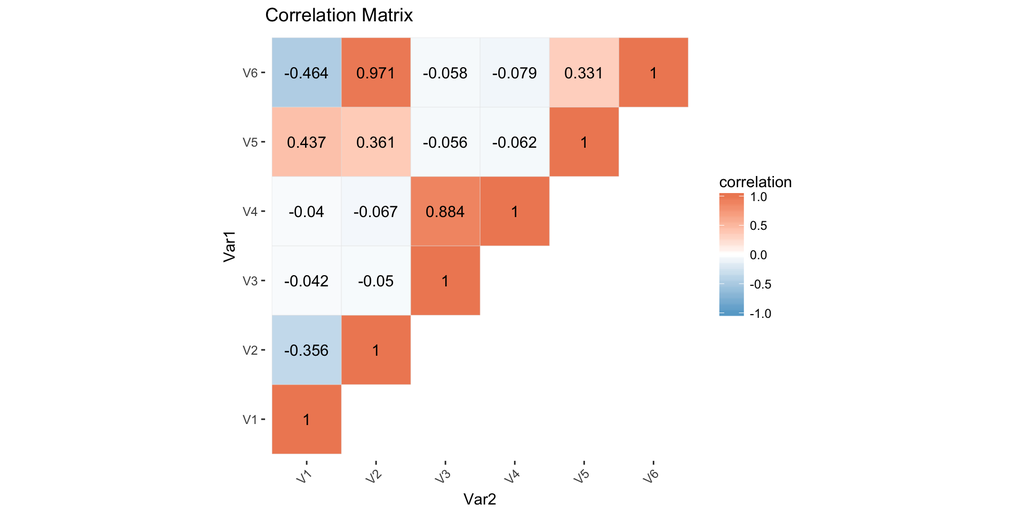

```r
cormat <- dat %>%
    cor(use = "complete.obs")
cormat[upper.tri(cormat)] <- NA

cormat %>%
    reshape2::melt(na.rm = TRUE) %>%
    ggplot(aes(Var2, Var1, fill = value)) +
    geom_tile(color = 'gray90') +
    geom_text(aes(label = round(value, 3))) +
    scale_fill_gradient2(low = "#67a9cf",
                         high = "#ef8a62",
                         limit = c(-1, 1),
                         name = "correlation") +
    coord_equal() +
    theme(axis.text.x = element_text(angle = 45, vjust = 1, hjust = 1),
          panel.background = element_blank()) +
    ggtitle("Correlation Matrix")
```

```r
# print just V1 correlations
cormat[2:6, 1]
```

```
##          V2          V3          V4          V5          V6
## -0.35631353 -0.04243960 -0.04011802  0.43695150 -0.46365281
```

# 3.

**Propose an initial model to fit the dataset**

```r
linear_model <- lm(V1 ~ ., data = dat)
summary(linear_model)
```

```
##
## Call:
## lm(formula = V1 ~ ., data = dat)
##
## Residuals:
##     Min      1Q  Median      3Q     Max
## -3.1103 -0.6338 -0.1098  0.5803  3.7018
##
## Coefficients:
##              Estimate Std. Error t value Pr(>|t|)
## (Intercept)   0.11085    0.25378   0.437    0.663
## V2            8.26752    1.14630   7.212  1.2e-11 ***
## V3            0.03651    0.15698   0.233    0.816
## V4           -0.27470    0.27790  -0.988    0.324
## V5            1.64357    0.11685  14.066  < 2e-16 ***
## V6          -11.83925    1.06907 -11.074  < 2e-16 ***
## ---
## Signif. codes:  0 '***' 0.001 '**' 0.01 '*' 0.05 '.' 0.1 ' ' 1
##
## Residual standard error: 1.058 on 194 degrees of freedom
## Multiple R-squared:  0.6916, Adjusted R-squared:  0.6836
## F-statistic:    87 on 5 and 194 DF,  p-value: < 2.2e-16
```

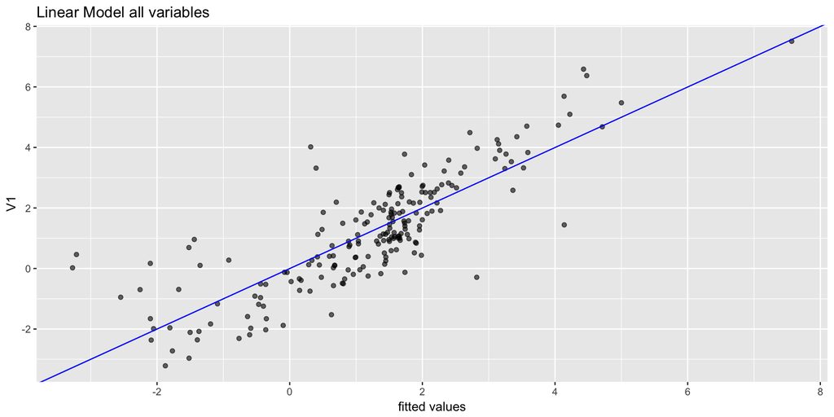

```r
broom::augment(linear_model) %>%
    ggplot(aes(.fitted, V1)) +
    geom_point(alpha = 0.6) +
    geom_abline(slope = 1, intercept = 0, color = "blue") +
    labs(x = "fitted values",
         title = "Linear Model all variables")
```

Not surprisingly, the three variables most correlated with `V1` yield significant coefficient estimates. The $R^2$ value is 0.6916, which should be improved.

# Explore

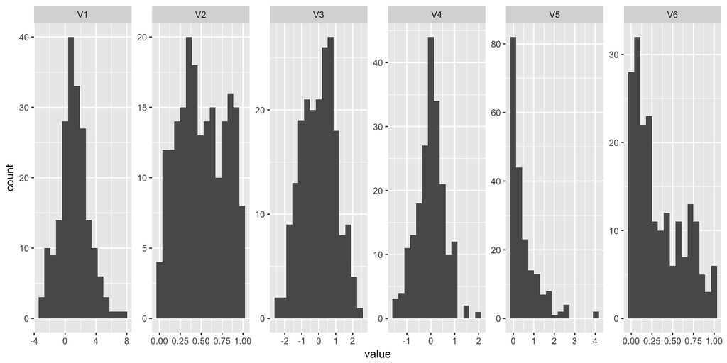

```r
# histograms of each variable
dat %>%
    gather("variable", "value") %>%
    ggplot(aes(value)) +
    geom_histogram(bins = 15) +
    facet_wrap(~variable, nrow = 1, scales = "free")
```

So, the response variable `V1` appears to be normally distributed. `V2` looks somewhat uniform, `V3` and `V4` normal but with different variances, `V5` skewed right, looks maybe poisson, and `V6` looks skweed right between 0 and 1.

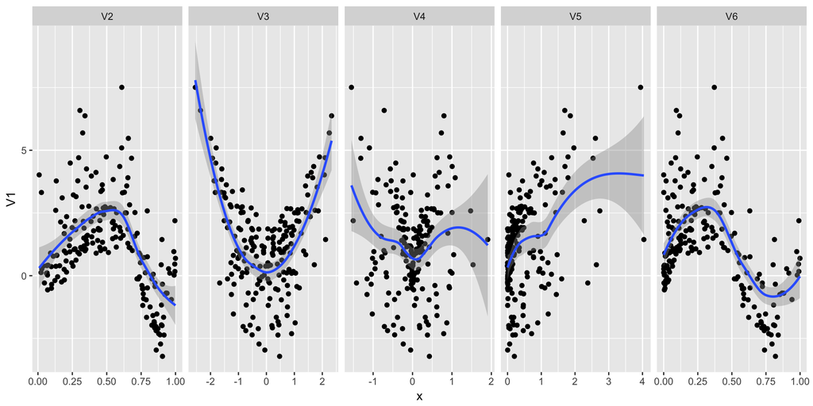

```r
# scatter plots vs V1
# fit loess smoothing to each plot
dat %>%
    gather("predictor", "x", 2:6) %>%
    ggplot(aes(x, V1)) +
    geom_point() +
    geom_smooth(method = "loess") +
    facet_wrap(~predictor, nrow = 1, scales = 'free_x')
```

Looks like `V2` and `V6` are cubic, while `V3` is quadratic. `V4` and `V5` require more investigation. Let’s look at transformations of `V5`.

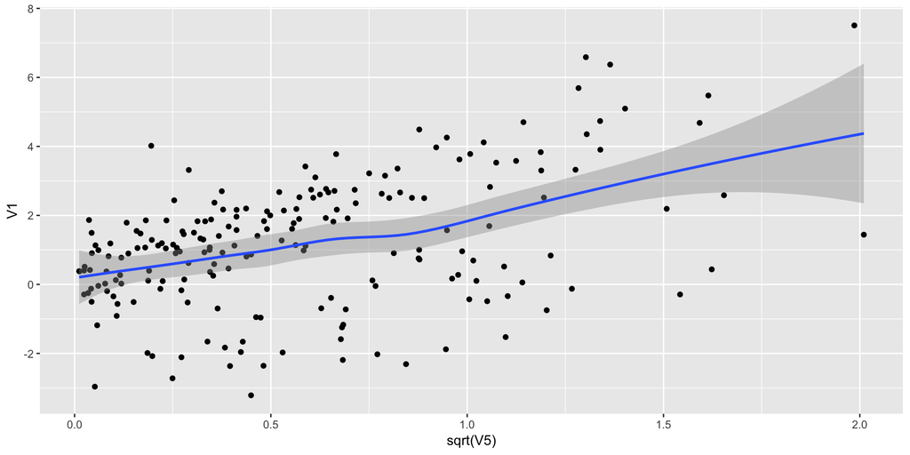

```r
ggplot(dat, aes(sqrt(V5), V1)) + geom_point() + geom_smooth()
```

Looks like a clearer relationship after square root transformation.

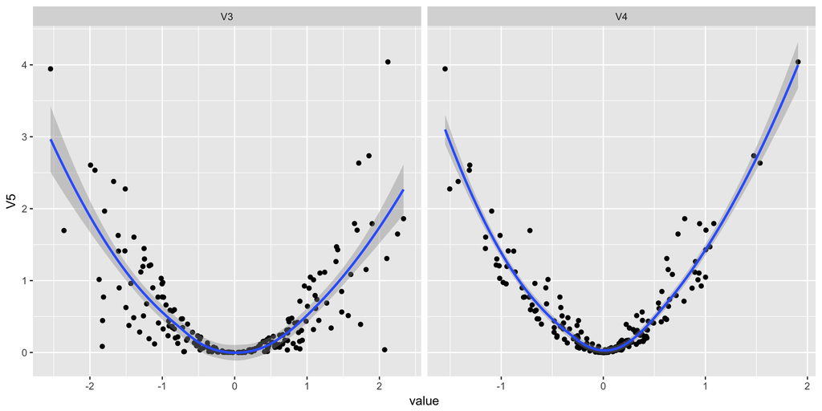

```r
# Is V5 dependendent on one of the other variables?
dat %>%
    gather("variable", "value", V3, V4) %>%
    ggplot(aes(value, V5)) +
    geom_point() +
    geom_smooth() +
    facet_wrap(~variable, nrow = 1, scales = "free_x")
```

Looks like `V5` might be a quadratic function of `V4` plus heteroskedastic error. Try to simulate this result.

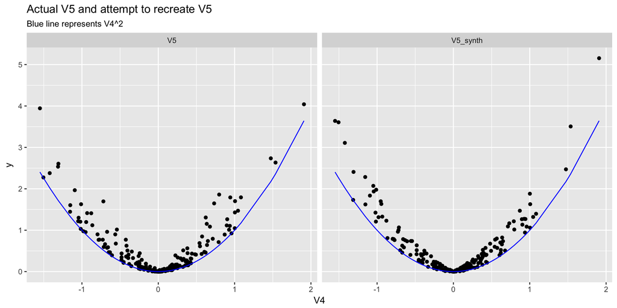

```r
dat %>%
    mutate(V5_synth = map_dbl(V4, ~.x^2 + runif(1, max = abs(.x)))) %>%
    gather("V", "y", V5, V5_synth) %>%
    ggplot(aes(V4, y)) +
    geom_point() +
    geom_line(aes(y = V4^2), color = "blue") +
    facet_wrap(~V) +
    labs(title = "Actual V5 and attempt to recreate V5",
         subtitle = "Blue line represents V4^2")
```

This isn’t quite right, but its close. `V5` is nonnegative, becaue it is the result of a square + some positive random error.

So `V5` is a quadratic function of `V4`. But it’s not just a synthesis from V4 + noise, the error is heteroskedastic, increasing with distance from 0. Next, investigate `V4`

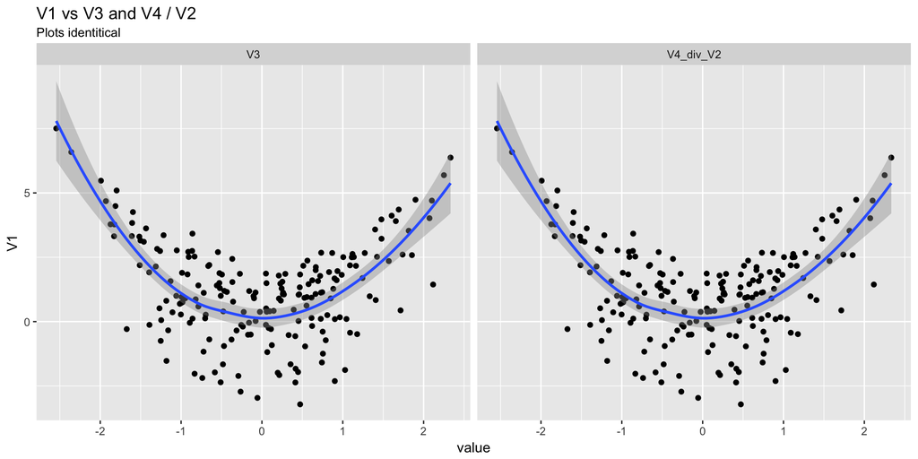

```r
# hypothesis that V4 = V3 * V2
dat %>%
    mutate(V4_div_V2 = V4 / V2) %>%
    gather("predictor", "value", V3, V4_div_V2) %>%
    ggplot(aes(value, V1)) +
    geom_point() +
    geom_smooth(method = "loess") +
    facet_wrap(~predictor) +
    labs(title = "V1 vs V3 and V4 / V2",
         subtitle = "Plots identitical")
```

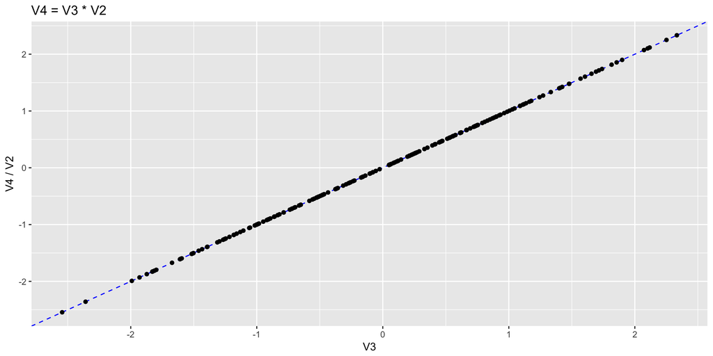

```r
# show that V3 = V4 / V2
dat %>%
    mutate(V4_div_V2 = V4 / V2) %>%
    ggplot(aes(V3, V4_div_V2)) +
    geom_abline(slope = 1, intercept = 0, color = 'blue', linetype = "dashed") +
    geom_point() +
    labs(y = "V4 / V2",
         title = "V4 = V3 * V2")
```

So, if $\frac{V_4}{V_2} = V_3$, then $V_4 = V_3V_2$

`V6` appears to be a transformation of `V2`

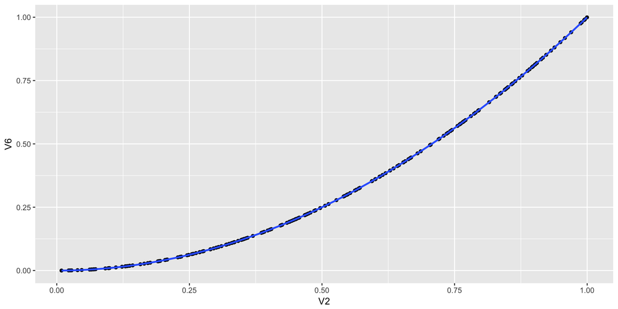

```r
ggplot(dat, aes(V2, V6)) + geom_point() + geom_smooth()
```

Test hypothesis that `V6` is a quadratic function of `V2`

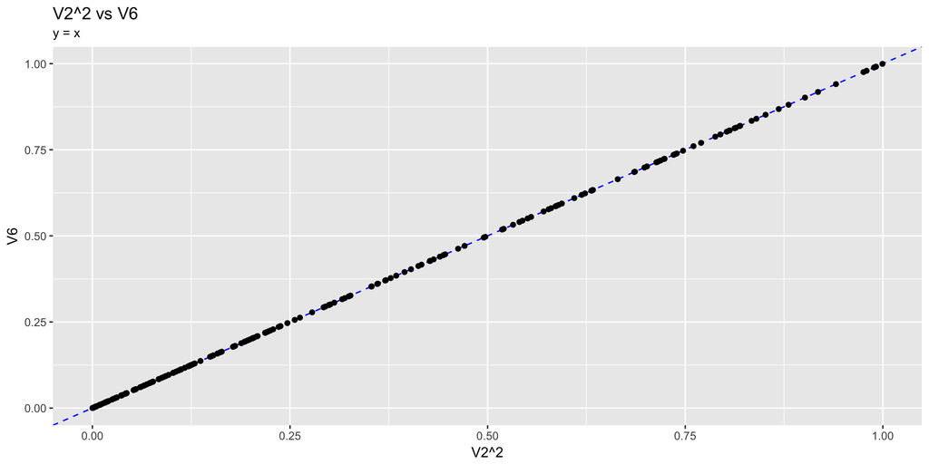

```r
ggplot(dat, aes(V2^2, V6)) +
    geom_abline(slope = 1, intercept = 0, color = 'blue', linetype = 'dashed') +
    geom_point() +
    labs(title = "V2^2 vs V6",
         subtitle = "y = x")
```

So, $V6 = V2^2$

### Hypothesis so far

So, we can relabel our data set:  
- `V2` random uniform  
- `V3` random normal  
- `V4` = `V2 * V3`  
- `V5` = `V4^2 + e`  
- `V6` = `V2^2`

# 4.

**Refined model based on exploratory analysis**

```r
mdl <- lm(V1 ~ poly(V3, 2) + poly(V6, 3), data = dat)
summary(mdl)
```

```
##
## Call:
## lm(formula = V1 ~ poly(V3, 2) + poly(V6, 3), data = dat)
##
## Residuals:
##      Min       1Q   Median       3Q      Max
## -1.30105 -0.34547 -0.04391  0.43553  1.19323
##
## Coefficients:
##               Estimate Std. Error t value Pr(>|t|)
## (Intercept)    1.20337    0.03733  32.235  < 2e-16 ***
## poly(V3, 2)1  -1.77034    0.52905  -3.346 0.000983 ***
## poly(V3, 2)2  17.03034    0.52982  32.143  < 2e-16 ***
## poly(V6, 3)1 -11.69643    0.52930 -22.098  < 2e-16 ***
## poly(V6, 3)2  -6.01169    0.52932 -11.357  < 2e-16 ***
## poly(V6, 3)3  12.03176    0.52820  22.779  < 2e-16 ***
## ---
## Signif. codes:  0 '***' 0.001 '**' 0.01 '*' 0.05 '.' 0.1 ' ' 1
##
## Residual standard error: 0.5279 on 194 degrees of freedom
## Multiple R-squared:  0.9232, Adjusted R-squared:  0.9213
## F-statistic: 466.6 on 5 and 194 DF,  p-value: < 2.2e-16
```

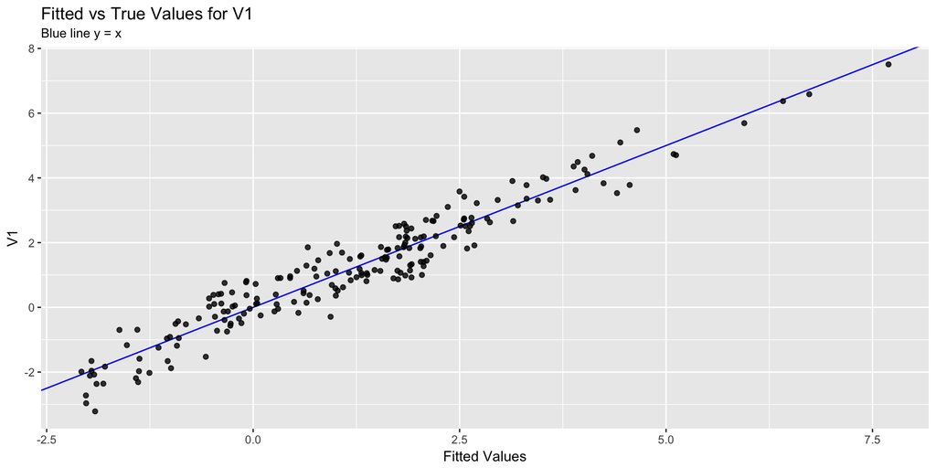

```r
broom::augment(mdl) %>%
    ggplot(aes(.fitted, V1)) +
    geom_abline(slope = 1, intercept = 0, color = 'blue') +
    geom_point(alpha = 0.8) +
    labs(x = "Fitted Values",
         title = "Fitted vs True Values for V1",
         subtitle = "Blue line y = x")
```

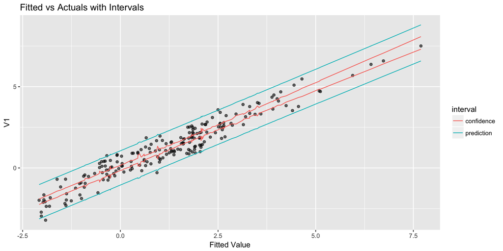

```r
# get confidence intervals for fit
conf_ints <- data.frame(predict(mdl, dat, interval = "confidence")) %>%
    rename(lwr_c = lwr, upr_c = upr)

# get prediction intervals for fit
pred_ints <- data.frame(predict(mdl, dat, interval = "prediction")) %>%
    rename(lwr_p = lwr, upr_p = upr)

# plot fitted vs actuals with intervals
inner_join(pred_ints, conf_ints, by = "fit") %>%
    bind_cols(select(dat, V1), .) %>%
    gather("bound", "value", lwr_p:upr_c) %>%
    mutate(interval = ifelse(grepl("p$", bound),
                             "prediction",
                             "confidence")) %>%
    ggplot(aes(x = fit)) +
        geom_point(aes(y = V1), alpha = 0.2) +
        geom_line(aes(y = value, group = bound, color = interval)) +
    labs(x = "Fitted Value",
         title = "Fitted vs Actuals with Intervals")
```

# 5.

**Attempt to Improve Model Further**

It is unlikely that the model can be improved further, as it is likely the remaining error is due to irreducible error. However, an attempt will be made by using regularized regression.

```r
# random seed for reproducibility
set.seed(6115)

# use 5-fold cross validation to choose lambda for ridge regression
doMC::registerDoMC(cores=4)

# model matrix
X = cbind(poly(dat$V3, 2), poly(dat$V6, 3))
y = dat$V1

# fit ridge regression (L2 penalty)
ridge <- glmnet::cv.glmnet(X, y,
                           alpha = 0,
                           nfolds = 5,
                           nlambda = 200,
                           parallel = TRUE)

# get ridge predictions
ridge_predictions <- predict(ridge, newx = X, s = "lambda.min")

# compare RMSE
(rmse <- c("RMSE_lm" = sqrt(mean(mdl$residuals^2)),
          "RMSE_ridge" = sqrt(mean((ridge_predictions - y)^2))))
```

```
##    RMSE_lm RMSE_ridge
##  0.5199624  0.5323926
```

It appears the ridge penalty adds too much bias. Visualize:

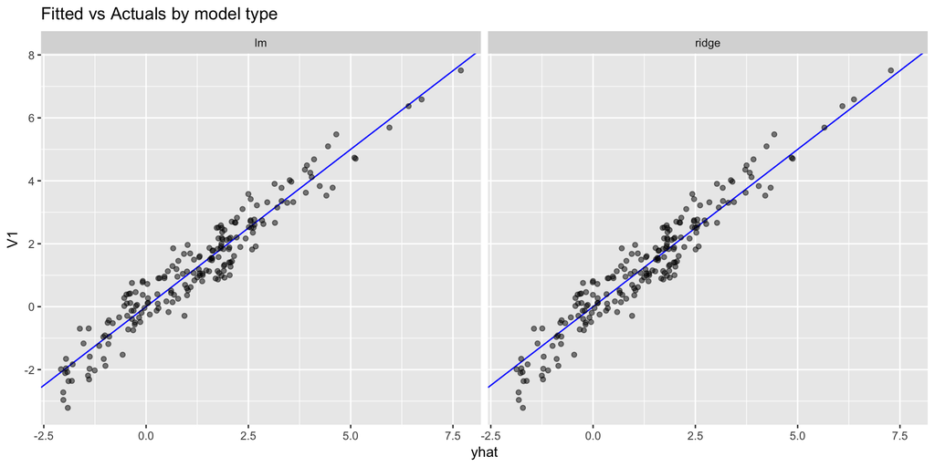

```r
data_frame(V1 = dat$V1,
           lm = mdl$fitted.values,
           ridge = as.numeric(ridge_predictions)) %>%
    gather("model", "yhat", lm, ridge) %>%
    ggplot(aes(yhat, V1)) +
    geom_abline(slope = 1, intercept = 0, color = 'blue') +
    geom_point(alpha = 0.5) +
    facet_wrap(~model) +
    ggtitle("Fitted vs Actuals by model type")
```

# 5.

**Final Model**

```r
# estimates with 95% confidence intervals
knitr::kable(broom::tidy(mdl, conf.int = TRUE))
```

| term | estimate | std.error | statistic | p.value | conf.low | conf.high |
| --- | --- | --- | --- | --- | --- | --- |
| (Intercept) | 1.203370 | 0.0373311 | 32.235035 | 0.0000000 | 1.129743 | 1.2769972 |
| poly(V3, 2)1 | -1.770341 | 0.5290469 | -3.346284 | 0.0009834 | -2.813763 | -0.7269193 |
| poly(V3, 2)2 | 17.030344 | 0.5298235 | 32.143429 | 0.0000000 | 15.985390 | 18.0752979 |
| poly(V6, 3)1 | -11.696427 | 0.5292976 | -22.098015 | 0.0000000 | -12.740343 | -10.6525104 |
| poly(V6, 3)2 | -6.011685 | 0.5293168 | -11.357442 | 0.0000000 | -7.055639 | -4.9677307 |
| poly(V6, 3)3 | 12.031759 | 0.5281987 | 22.778849 | 0.0000000 | 10.990010 | 13.0735080 |

*Note that all coefficient estimates are statistically significant*